# PCA in R

**Function Docs Refresher**

### What we cover:

1. How to use the `prcomp()` function to do PCA
2. How to draw a PCA plot using *base graphics* and *ggplot2*
3. How to determine how much variation each principal component accounts for
4. How to examine the loading scores to determine what variables have the largest effect on the graph

### Generate a dataset

First, let’s generate a fake dataset that we can use in the demonstration

- `wt` - wild type - samples are the normal, every day samples
- `ko` - knock-out - samples are samples that are missing a gene because we knocked it out

```r
data.matrix <- matrix(nrow = 100, ncol = 10)

# name the samples
colnames(data.matrix) <- c( # combines the two vectors, assign them as clumn names
  paste0("wt", 1:5), # creates wt1...wt5
  paste0("ko", 1:5) # creates ko1...ko5
)

# name the genes
rownames(data.matrix) <- paste0("gene", 1:100)

# give the fake genes fake read counts
for (i in 1:100) {
  wt.values <- rpois(5, lambda = sample(x = 10:1000, size = 1))
  ko.values <- rpois(5, lambda = sample(x = 10:1000, size = 1))

  data.matrix[i,] <- c(wt.values, ko.values)
}

head(data.matrix)
```

```
      wt1 wt2 wt3 wt4 wt5 ko1 ko2 ko3 ko4 ko5
gene1 934 922 930 954 976 921 954 915 860 932
gene2 354 363 404 383 383 582 558 585 593 586
gene3 585 567 625 586 581 217 167 207 203 175
gene4 310 307 333 282 274 724 756 715 684 700
gene5 225 189 202 212 205 397 389 459 377 373
gene6 421 409 436 451 433 395 401 378 412 359
```

### Doing PCA

- The goal is to draw a graph to show how the samples are related (or not related) to each other
- By default `prcomp()` expects the samples to be rows and the genes to be columns
- Since the samples in our data matrix are columns, and the genes (variables) are rows we have to transpose the matrix using the `t()` function
- `prcomp()` returns three things:
  1. `x` Contains the principal components (PCs) for drawing a graph. Here we are using the first two columns in `x` to draw a 2-D plot that uses the first two PCs. Even though overall there are 10 PCs (since there are 10 samples). The first PC accounts for the most variation in the original data, the second PC for the second most and so on. We use frst two PCs to plot a 2D PCA graph. However, sometimes we use PC2 and PC3.
  2. `sdev` Stands for “standard deviation”. We use it to calculate how much variation in the original data each principal component accounts for.
  3. `rotation`
- PC1 is on the x-axis, because it is the first column in `x`
- PC2 is on the y-axis

To get a sense of how meaningful these clusters are, let’s see how much variation in the original data PC1 accounts for. For that we use the square of `sdev`.

Looking at the plot with calculated variations we can see that PC1 accounts for almost all the data variation in the data. This means that there is a big difference between those two clusters.

Breakdown of `ggplot()`:

1. Pass in the `pca.data` dataframe and tell **ggplot** which columns contain the X and Y coordinates and which column has the sample labels
2. `geom_text()` - plot the labels, rather than dots or some other shape
3. `xlab()` and `ylab()` to add X and Y axis labels.

Lastly, let’s look at how to use **loading scores** to determine which genes have the largest effect on where samples are plotted in the PCA plot.

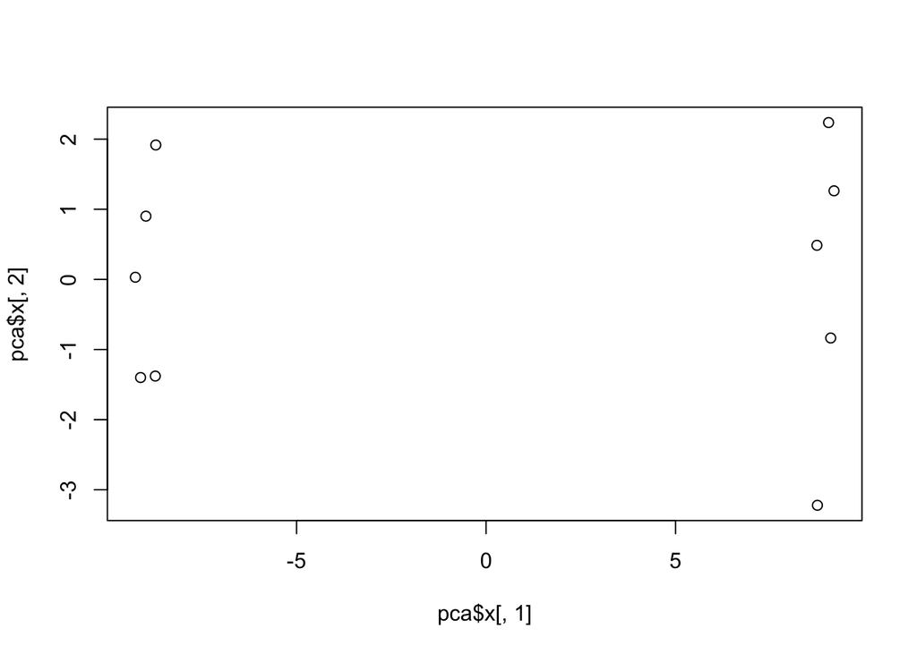

```r
pca <- prcomp(t(data.matrix), scale = TRUE)
plot(pca$x[,1], pca$x[,2])
```

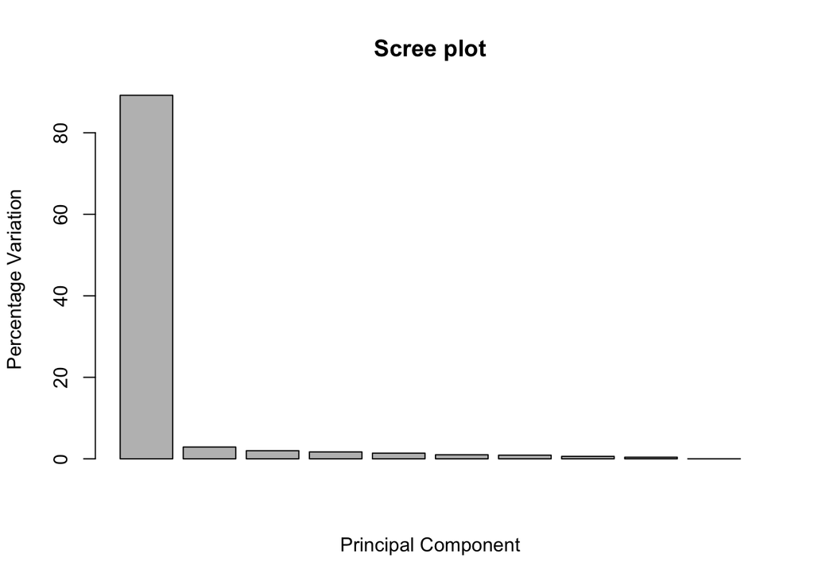

```r
# Calculate variation
pca.var <- pca$sdev^2

# Calculate the percentages
pca.var.per <- round(pca.var/sum(pca.var)*100, 1)

# Plot the percentages
barplot(pca.var.per, main = "Scree plot", xlab = "Principal Component", ylab = "Percentage Variation")

library(ggplot2)
```

```r
pca.data <- data.frame(Sample=rownames(pca$x),
                       X=pca$x[,1],
                       Y=pca$x[,2])
pca.data
```

|  | Sample | X | Y |
| --- | --- | --- | --- |
| wt1 | wt1 | -9.252533 | 0.03073577 |
| wt2 | wt2 | -8.713082 | 1.91680011 |
| wt3 | wt3 | -8.974121 | 0.90161489 |
| wt4 | wt4 | -8.726308 | -1.37847521 |
| wt5 | wt5 | -9.114756 | -1.39956747 |
| ko1 | ko1 | 9.180340 | 1.26317103 |
| ko2 | ko2 | 9.036592 | 2.23678529 |
| ko3 | ko3 | 9.092661 | -0.83597204 |
| ko4 | ko4 | 8.742145 | -3.22135827 |
| ko5 | ko5 | 8.729062 | 0.48626588 |

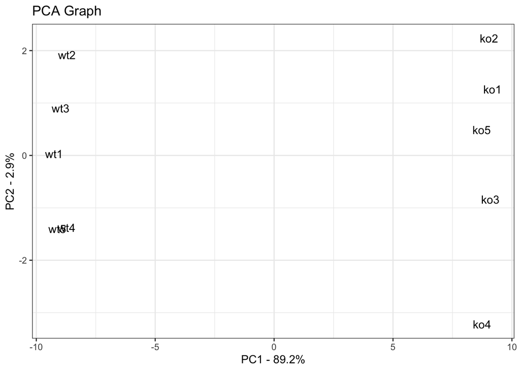

```r
ggplot(data = pca.data, aes(x=X, y=Y, label=Sample)) +
        geom_text() +
        xlab(paste0("PC1 - ", pca.var.per[1], "%")) +
        ylab(paste0("PC2 - ", pca.var.per[2], "%")) +
        theme_bw() +
        ggtitle("PCA Graph")
```

```r
# Loadinf scores
loading_scores <- pca$rotation[,1]
gene_scores <- abs(loading_scores)
gene_scores_ranked <- sort(gene_scores, decreasing = TRUE)
top_10_genes <- names(gene_scores_ranked[1:10])

top_10_genes
```

```
 [1] "gene28" "gene95" "gene72" "gene8"  "gene23" "gene20" "gene50" "gene82"
 [9] "gene61" "gene21"
```

[output not shown]

```r
pca$rotation[top_10_genes, 1] # show the scores (now with +/- sign)
```

```
    gene28     gene95     gene72      gene8     gene23     gene20     gene50
-0.1058641  0.1058508  0.1058189 -0.1058178  0.1058168 -0.1058090  0.1058080
    gene82     gene61     gene21
-0.1058079 -0.1058046 -0.1057803
```